# Data Extraction, Exploratory Data Analysis (EDA)

## Importación de Librerías

Para llevar a cabo el análisis exploratorio de datos, es esencial importar las librerías necesarias que nos permitirán manejar los datos, visualizarlos y analizar sus características.

```python
import numpy as np
import pandas as pd
import seaborn as sns
import matplotlib.pyplot as plt
```

## Carga de Datos

Para comenzar el análisis exploratorio, primero necesitamos cargar los datos que vamos a analizar. En este caso, estamos trabajando con un archivo CSV que contiene los resultados de una encuesta sobre la satisfacción del cliente de una aerolínea.

```python
data = pd.read_csv(r'C:\Users\pc-admin\Documents\Proyectos Data\Customer_Satisfaction\Encuesta.csv')
data.head()
```

|  | Unnamed: 0 | Gender | customer_type | age | type_of_travel | customer_class | flight_distance | inflight_wifi_service | departure_arrival_time_convenient | ease_of_online_booking | ... | inflight_entertainment | onboard_service | leg_room_service | baggage_handling | checkin_service | inflight_service | cleanliness | departure_delay_in_minutes | arrival_delay_in_minutes | satisfaction |
| --- | --- | --- | --- | --- | --- | --- | --- | --- | --- | --- | --- | --- | --- | --- | --- | --- | --- | --- | --- | --- | --- |
| 0 | 39463 | Female | disloyal Customer | 46 | Business travel | Eco | 406 | 3 | 0 | 4 | ... | 5 | 1 | 5 | 4 | 2 | 4 | 5 | 0 | 17.0 | neutral or dissatisfied |
| 1 | 39464 | Male | Loyal Customer | 24 | Business travel | Eco | 479 | 4 | 3 | 3 | ... | 4 | 2 | 2 | 1 | 4 | 1 | 4 | 0 | 0.0 | neutral or dissatisfied |
| 2 | 39467 | Male | Loyal Customer | 63 | Business travel | Business | 2009 | 2 | 3 | 3 | ... | 2 | 2 | 2 | 2 | 3 | 2 | 2 | 0 | 30.0 | neutral or dissatisfied |
| 3 | 39470 | Male | Loyal Customer | 38 | Business travel | Business | 1984 | 1 | 4 | 5 | ... | 1 | 1 | 2 | 1 | 1 | 1 | 4 | 2 | 0.0 | neutral or dissatisfied |
| 4 | 39471 | Female | Loyal Customer | 35 | Personal Travel | Eco | 2288 | 1 | 3 | 2 | ... | 3 | 2 | 1 | 4 | 2 | 4 | 3 | 0 | 0.0 | neutral or dissatisfied |

5 rows × 24 columns

## Resumen Estadístico de los Datos

Una vez que los datos han sido cargados correctamente, el siguiente paso es obtener un resumen estadístico de las variables numéricas del conjunto de datos. Esto proporciona una visión general de las principales características estadísticas de cada variable, como la media, desviación estándar, valores mínimos y máximos, entre otros.

```python
# Resumen estadístico
print(data.describe())
```

```
          Unnamed: 0           age  flight_distance  inflight_wifi_service  \
count   71892.000000  71892.000000     71892.000000           71892.000000
mean    91056.520642     39.411423      1179.221888               2.707408
std     24840.235631     15.216180       991.742638               1.313077
min     39463.000000      7.000000        31.000000               0.000000
25%     75484.500000     27.000000       409.000000               2.000000
50%     93465.500000     40.000000       836.000000               3.000000
75%    111765.250000     51.000000      1724.000000               4.000000
max    129879.000000     85.000000      4983.000000               5.000000

       departure_arrival_time_convenient  ease_of_online_booking  \
count                       71892.000000            71892.000000
mean                            3.059784                2.748192
std                             1.524496                1.394226
min                             0.000000                0.000000
25%                             2.000000                2.000000
50%                             3.000000                3.000000
75%                             4.000000                4.000000
max                             5.000000                5.000000

       gate_location  food_and_drink  online_boarding  seat_comfort  \
count   71892.000000    71892.000000     71892.000000  71892.000000
mean        2.982835        3.192803         3.224782      3.418600
std         1.273073        1.330704         1.347681      1.321368
min         0.000000        0.000000         0.000000      1.000000
25%         2.000000        2.000000         2.000000      2.000000
50%         3.000000        3.000000         3.000000      4.000000
75%         4.000000        4.000000         4.000000      4.000000
max         5.000000        5.000000         5.000000      5.000000

       inflight_entertainment  onboard_service  leg_room_service  \
count            71892.000000     71892.000000      71892.000000
mean                 3.332680         3.365145          3.334057
std                  1.338945         1.288575          1.318916
min                  0.000000         0.000000          0.000000
25%                  2.000000         2.000000          2.000000
50%                  4.000000         4.000000          4.000000
75%                  4.000000         4.000000          4.000000
max                  5.000000         5.000000          5.000000

       baggage_handling  checkin_service  inflight_service   cleanliness  \
count      71892.000000     71892.000000      71892.000000  71892.000000
mean           3.619207         3.293218          3.630821      3.267401
std            1.180144         1.268619          1.177874      1.316923
min            1.000000         1.000000          0.000000      0.000000
25%            3.000000         2.000000          3.000000      2.000000
50%            4.000000         3.000000          4.000000      3.000000
75%            5.000000         4.000000          5.000000      4.000000
max            5.000000         5.000000          5.000000      5.000000

       departure_delay_in_minutes  arrival_delay_in_minutes
count                71892.000000              71676.000000
mean                    14.719246                 15.161072
std                     38.158946                 38.501499
min                      0.000000                  0.000000
25%                      0.000000                  0.000000
50%                      0.000000                  0.000000
75%                     12.000000                 13.000000
max                   1592.000000               1584.000000
```

## Resumen Estadístico de las Variables Numéricas

A continuación, se presenta un resumen estadístico de las variables numéricas del conjunto de datos. Este resumen proporciona información esencial sobre la distribución de los datos, como la media, la desviación estándar, y los percentiles, que son útiles para entender mejor las características de cada variable.

### Resumen Estadístico

| Variable | count | mean | std | min | 25% | 50% | 75% | max |
| --- | --- | --- | --- | --- | --- | --- | --- | --- |
| **Unnamed: 0** | 71,892 | 91,056.52 | 24,840.24 | 39,463.00 | 75,484.50 | 93,465.50 | 111,765.25 | 129,879.00 |
| **age** | 71,892 | 39.41 | 15.22 | 7.00 | 27.00 | 40.00 | 51.00 | 85.00 |
| **flight_distance** | 71,892 | 1,179.22 | 991.74 | 31.00 | 409.00 | 836.00 | 1,724.00 | 4,983.00 |
| **inflight_wifi_service** | 71,892 | 2.71 | 1.31 | 0.00 | 2.00 | 3.00 | 4.00 | 5.00 |
| **departure_arrival_time_convenient** | 71,892 | 3.06 | 1.52 | 0.00 | 2.00 | 3.00 | 4.00 | 5.00 |
| **ease_of_online_booking** | 71,892 | 2.75 | 1.39 | 0.00 | 2.00 | 3.00 | 4.00 | 5.00 |
| **gate_location** | 71,892 | 2.98 | 1.27 | 0.00 | 2.00 | 3.00 | 4.00 | 5.00 |
| **food_and_drink** | 71,892 | 3.19 | 1.33 | 0.00 | 2.00 | 3.00 | 4.00 | 5.00 |
| **online_boarding** | 71,892 | 3.22 | 1.35 | 0.00 | 2.00 | 3.00 | 4.00 | 5.00 |
| **seat_comfort** | 71,892 | 3.42 | 1.32 | 1.00 | 2.00 | 4.00 | 4.00 | 5.00 |
| **inflight_entertainment** | 71,892 | 3.33 | 1.34 | 0.00 | 2.00 | 4.00 | 4.00 | 5.00 |
| **onboard_service** | 71,892 | 3.37 | 1.29 | 0.00 | 2.00 | 4.00 | 4.00 | 5.00 |
| **leg_room_service** | 71,892 | 3.33 | 1.32 | 0.00 | 2.00 | 4.00 | 4.00 | 5.00 |
| **baggage_handling** | 71,892 | 3.62 | 1.18 | 1.00 | 3.00 | 4.00 | 5.00 | 5.00 |
| **checkin_service** | 71,892 | 3.29 | 1.27 | 1.00 | 2.00 | 3.00 | 4.00 | 5.00 |
| **inflight_service** | 71,892 | 3.63 | 1.18 | 0.00 | 3.00 | 4.00 | 5.00 | 5.00 |
| **cleanliness** | 71,892 | 3.27 | 1.32 | 0.00 | 2.00 | 3.00 | 4.00 | 5.00 |
| **departure_delay_in_minutes** | 71,892 | 14.72 | 38.16 | 0.00 | 0.00 | 0.00 | 12.00 | 1,592.00 |
| **arrival_delay_in_minutes** | 71,676 | 15.16 | 38.50 | 0.00 | 0.00 | 0.00 | 13.00 | 1,584.00 |

### Observaciones Clave:

1. **Edad (`age`)**:
   - La edad promedio de los clientes es de 39.41 años, con una desviación estándar de 15.22 años. La edad mínima es de 7 años y la máxima es de 85 años.
2. **Distancia de Vuelo (`flight_distance`)**:
   - La distancia de vuelo promedio es de 1,179.22 km, con una gran variabilidad (desviación estándar de 991.74 km). Esto sugiere una diversidad en las rutas de vuelo, desde cortas hasta muy largas.
3. **Comodidad del Asiento (`seat_comfort`)**:
   - La mediana para la comodidad del asiento es de 4 (sobre 5), lo que indica que muchos clientes califican positivamente esta característica, aunque existe variabilidad en las experiencias.
4. **Retrasos en la Salida (`departure_delay_in_minutes`)**:
   - El retraso promedio en la salida es de 14.72 minutos, pero con una desviación estándar alta de 38.16 minutos. Esto indica que algunos vuelos experimentan retrasos significativos.
5. **Retrasos en la Llegada (`arrival_delay_in_minutes`)**:
   - Similar a los retrasos en la salida, los retrasos en la llegada tienen una media de 15.16 minutos y una alta desviación estándar, sugiriendo una experiencia inconsistente.

### Importancia del Resumen:

Este resumen estadístico es crucial para identificar patrones generales en los datos y detectar posibles problemas como la presencia de valores atípicos. Proporciona una primera impresión de la calidad y distribución de los datos, que es fundamental para guiar el análisis exploratorio posterior y la preparación de los datos.

## Información General del DataFrame

Antes de proceder con análisis más detallados, es importante revisar la estructura general del DataFrame para comprender mejor el tipo de datos que contiene y detectar posibles problemas, como valores nulos o tipos de datos incorrectos.

```python
print(data.info())
```

```
<class 'pandas.core.frame.DataFrame'>
RangeIndex: 71892 entries, 0 to 71891
Data columns (total 24 columns):
 #   Column                             Non-Null Count  Dtype
---  ------                             --------------  -----
 0   Unnamed: 0                         71892 non-null  int64
 1   Gender                             71892 non-null  object
 2   customer_type                      71892 non-null  object
 3   age                                71892 non-null  int64
 4   type_of_travel                     71892 non-null  object
 5   customer_class                     71892 non-null  object
 6   flight_distance                    71892 non-null  int64
 7   inflight_wifi_service              71892 non-null  int64
 8   departure_arrival_time_convenient  71892 non-null  int64
 9   ease_of_online_booking             71892 non-null  int64
```

[output cut: 17 more lines]

## Análisis de Valores Nulos

Los valores nulos en un conjunto de datos pueden afectar significativamente la calidad del análisis y los modelos predictivos. Es fundamental identificar las columnas que contienen valores nulos y evaluar la magnitud del problema para decidir cómo manejarlos.

```python
# Definir la variable total_filas
total_filas = len(data)

# Ahora puedes proceder con el cálculo de los valores nulos y sus porcentajes
valores_nulos = data.isnull().sum()
porcentaje_nulos = (valores_nulos / total_filas) * 100

# Crear un DataFrame para mostrar ambos resultados
nulos_df = pd.DataFrame({
    'Valores Nulos': valores_nulos,
    'Porcentaje Nulos (%)': porcentaje_nulos
})

# Imprimir el resumen de valores nulos
print("Valores nulos y su porcentaje por columna:")
print(nulos_df)
```

```
Valores nulos y su porcentaje por columna:
                                   Valores Nulos  Porcentaje Nulos (%)
Unnamed: 0                                     0              0.000000
Gender                                         0              0.000000
customer_type                                  0              0.000000
age                                            0              0.000000
type_of_travel                                 0              0.000000
customer_class                                 0              0.000000
flight_distance                                0              0.000000
inflight_wifi_service                          0              0.000000
departure_arrival_time_convenient              0              0.000000
ease_of_online_booking                         0              0.000000
gate_location                                  0              0.000000
food_and_drink                                 0              0.000000
online_boarding                                0              0.000000
seat_comfort                                   0              0.000000
inflight_entertainment                         0              0.000000
onboard_service                                0              0.000000
leg_room_service                               0              0.000000
baggage_handling                               0              0.000000
checkin_service                                0              0.000000
inflight_service                               0              0.000000
cleanliness                                    0              0.000000
departure_delay_in_minutes                     0              0.000000
arrival_delay_in_minutes                     216              0.300451
satisfaction                                   0              0.000000
```

## Distribución de la Variable Objetivo: Satisfacción del Cliente

Es fundamental entender cómo se distribuye la variable objetivo, en este caso, la satisfacción del cliente (`satisfaction`). Analizar la cantidad de observaciones en cada categoría nos proporciona una idea clara de la proporción de clientes satisfechos e insatisfechos, lo que es crucial para orientar el análisis y la estrategia.

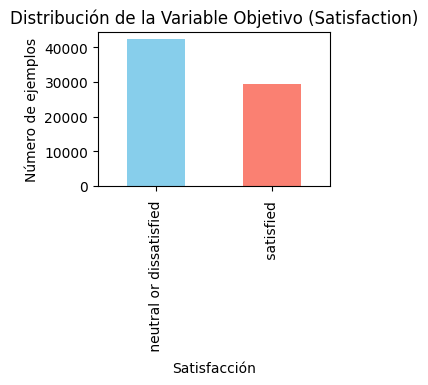

```python
# Contar la cantidad de instancias de cada clase en la columna 'satisfaction'
clase_counts = data['satisfaction'].value_counts()

# Ahora puedes graficar
plt.figure(figsize=(3, 2))
clase_counts.plot(kind='bar', color=['skyblue', 'salmon'])
plt.title('Distribución de la Variable Objetivo (Satisfaction)')
plt.xlabel('Satisfacción')
plt.ylabel('Número de ejemplos')
plt.show()
```

1. **Distribución Desbalanceada**:
   - Existe un desbalance en la variable objetivo, con más pasajeros clasificados como "neutral or dissatisfied" que como "satisfied". Esto sugiere que una parte considerable de los clientes no está completamente satisfecha con el servicio, lo cual es crítico para la aerolínea.
2. **Implicaciones para el Modelado**:
   - Dado el desbalance en las clases, podría ser necesario aplicar técnicas de balanceo de datos (como SMOTE) para evitar que el modelo esté sesgado hacia la clase mayoritaria.
3. **Enfoque Estratégico**:
   - La mayor proporción de clientes insatisfechos o neutrales representa una oportunidad significativa para mejorar el servicio. Es fundamental que la aerolínea identifique y aborde los factores específicos que están contribuyendo a esta insatisfacción.
4. **Acciones Recomendadas**:
   - Realizar un análisis más profundo para identificar las características que distinguen a los clientes satisfechos de los insatisfechos.
   - Desarrollar iniciativas para mejorar la experiencia del cliente, enfocándose en los aspectos que afectan más la satisfacción, como se detallará en análisis posteriores.

```python
print(data['arrival_delay_in_minutes'].describe())
print(data['arrival_delay_in_minutes'].value_counts())
```

```
count    71676.000000
mean        15.161072
std         38.501499
min          0.000000
25%          0.000000
50%          0.000000
75%         13.000000
max       1584.000000
Name: arrival_delay_in_minutes, dtype: float64
arrival_delay_in_minutes
0.0      40165
1.0       1510
2.0       1421
4.0       1322
3.0       1303
         ...
448.0        1
370.0        1
371.0        1
366.0        1
319.0        1
Name: count, Length: 416, dtype: int64
```

# Identificación de Outliers con Boxplots

Este script se utiliza para generar boxplots que permitan identificar la presencia de valores atípicos (outliers) en el conjunto de datos. La identificación de estos outliers es crucial, ya que serán eliminados en pasos posteriores del análisis.

## Selección de Columnas para Visualización

Primero, definimos las columnas que queremos analizar mediante boxplots para identificar posibles outliers.

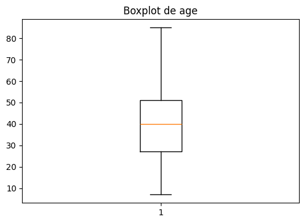

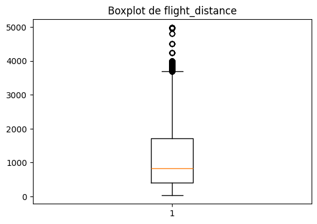

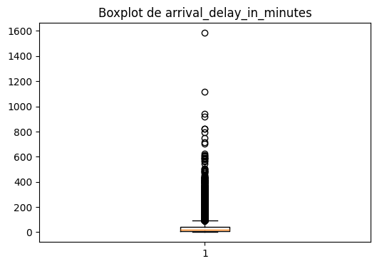

```python
# Definir la lista de columnas que quieres visualizar
columns_to_plot = ['age', 'flight_distance', 'departure_delay_in_minutes']

# Crear un boxplot para las columnas de 'age', 'flight_distance' y 'departure_delay_in_minutes'
for col in columns_to_plot[:-1]:  # Excluyendo 'arrival_delay_in_minutes' para tratamiento especial
    plt.figure(figsize=(6, 4))
    plt.boxplot(data[col])
    plt.title(f'Boxplot de {col}')
    plt.show()
    # Filtrar valores mayores a 0 en 'arrival_delay_in_minutes'
filtered_data = data['arrival_delay_in_minutes'][data['arrival_delay_in_minutes'] > 0]

# Crear el boxplot con los datos filtrados
plt.figure(figsize=(6, 4))
plt.boxplot(filtered_data)
plt.title('Boxplot de arrival_delay_in_minutes')
plt.show()
```

## Visualización de la Relación entre Edad y Satisfacción

Para entender mejor cómo la edad del cliente puede influir en su satisfacción, es útil visualizar la distribución de la edad dentro de las distintas categorías de satisfacción (`satisfied` y `neutral or dissatisfied`). Un boxplot es una herramienta efectiva para este propósito, ya que permite comparar las distribuciones y detectar posibles diferencias o patrones.

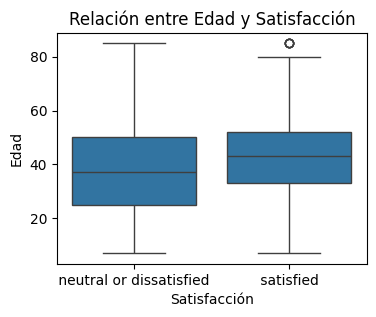

```python
plt.figure(figsize=(4, 3))
sns.boxplot(x='satisfaction', y='age', data=data)
plt.title('Relación entre Edad y Satisfacción')
plt.xlabel('Satisfacción')
plt.ylabel('Edad')
plt.show()
```

## Distribución de la Distancia de Vuelo por Satisfacción

Para comprender cómo la distancia de vuelo puede influir en la satisfacción del cliente, es útil visualizar la distribución de esta variable en función de la satisfacción del cliente. Se usará un histograma con KDE (Kernel Density Estimate) como herramienta para observar la densidad y frecuencia de las distancias de vuelo para clientes satisfechos e insatisfechos.

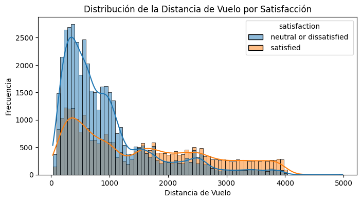

```python
plt.figure(figsize=(8, 4))
sns.histplot(data=data, x='flight_distance', hue='satisfaction', kde=True)
plt.title('Distribución de la Distancia de Vuelo por Satisfacción')
plt.xlabel('Distancia de Vuelo')
plt.ylabel('Frecuencia')
plt.show()
```

1. **Distribución de la Distancia de Vuelo**:
   - La mayoría de los vuelos se concentran en distancias cortas (menos de 1,000 km), tanto para pasajeros satisfechos como insatisfechos.
2. **Patrones de Satisfacción por Distancia**:
   - Los vuelos cortos muestran una mayor proporción de pasajeros insatisfechos, mientras que en vuelos largos, la satisfacción aumenta.
3. **Implicaciones para el Servicio**:
   - Los vuelos cortos presentan un desafío mayor en términos de satisfacción del cliente, posiblemente debido a la duración limitada del servicio o restricciones en la atención.
4. **Acciones Recomendadas**:
   - Investigar y mejorar los factores que afectan la satisfacción en vuelos cortos, como la eficiencia en el embarque o la calidad del servicio a bordo.

## Satisfacción por Tipo de Viaje y Clase de Cliente

Para comprender cómo el tipo de viaje y la clase de cliente influyen en la satisfacción, es útil visualizar la distribución de clientes en cada categoría de tipo de viaje, desglosada por clase de cliente. Un countplot es una herramienta eficaz para mostrar el número de clientes en cada categoría, permitiendo comparaciones claras entre grupos.

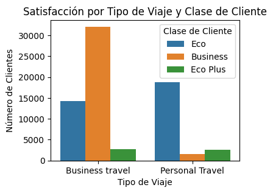

```python
plt.figure(figsize=(4, 3))
sns.countplot(x='type_of_travel', hue='customer_class', data=data)
plt.title('Satisfacción por Tipo de Viaje y Clase de Cliente')
plt.xlabel('Tipo de Viaje')
plt.ylabel('Número de Clientes')
plt.legend(title='Clase de Cliente')
plt.show()
```

1. **Distribución de Clientes por Tipo de Viaje y Clase**:
   - Los viajes de negocios son principalmente realizados por clientes en clase Business, mientras que los viajes personales son predominantemente en clase Económica (Eco).
2. **Segmentación de Mercado**:
   - La clase Business es clave para los viajeros de negocios que buscan comodidad y eficiencia. En contraste, los viajeros personales en clase Económica tienden a ser más sensibles al precio.
3. **Implicaciones para la Estrategia de Servicio**:
   - Asegurar que los servicios en clase Business satisfacen a los viajeros de negocios.
   - Optimizar la experiencia en clase Económica para viajeros personales podría aumentar su satisfacción y lealtad.
4. **Acciones Recomendadas**:
   - Implementar programas de lealtad para viajeros frecuentes en clase Business.
   - Mejorar la eficiencia en el embarque y la comodidad en clase Económica para captar y retener a los viajeros personales.

Este resumen proporciona una visión clara de la segmentación de los clientes y las oportunidades estratégicas para mejorar su experiencia.

## Distribución de la Satisfacción por Clase y Tipo de Viaje

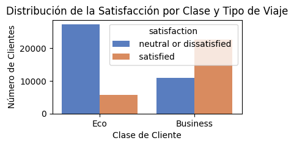

```python
plt.figure(figsize=(4, 2))

# Graficar la distribución de la satisfacción dentro de cada clase y tipo de viaje
sns.countplot(
    data=data[(data['customer_class'].isin(['Eco', 'Business'])) &
              (data['type_of_travel'].isin(['Business travel', 'Personal Travel']))],
    x='customer_class',
    hue='satisfaction',
    palette="muted"
)

plt.title('Distribución de la Satisfacción por Clase y Tipo de Viaje')
plt.xlabel('Clase de Cliente')
plt.ylabel('Número de Clientes')
plt.show()
```

## Análisis de Características del Servicio por Clase y Satisfacción

Para entender cómo diferentes características del servicio influyen en la satisfacción del cliente, se visualizan las puntuaciones de varias características clave (`seat_comfort`, `food_and_drink`, `inflight_entertainment`, `onboard_service`) desglosadas por clase de cliente (`Eco`, `Business`) y nivel de satisfacción (`satisfied`, `neutral or dissatisfied`). Los boxplots permiten comparar estas distribuciones y detectar patrones en la experiencia del cliente.

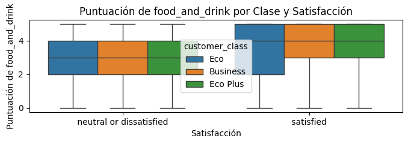

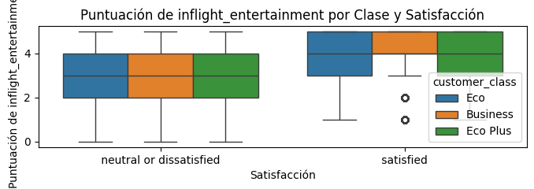

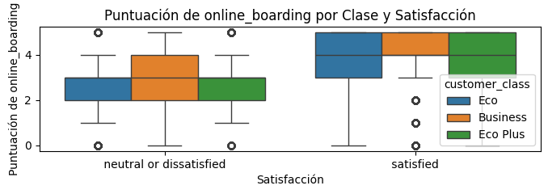

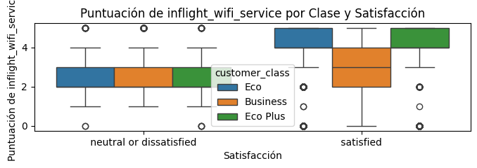

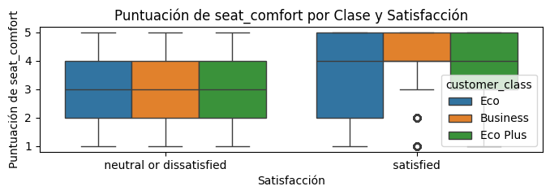

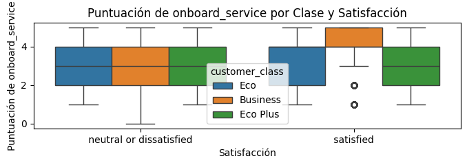

```python
service_features = ['food_and_drink','inflight_entertainment','online_boarding','inflight_wifi_service','seat_comfort','onboard_service']

for feature in service_features:
    plt.figure(figsize=(8, 2))
    sns.boxplot(x='satisfaction', y=feature, hue='customer_class',
                data=data[data['customer_class'].isin(['Eco', 'Business', 'Eco Plus'])])
    plt.title(f'Puntuación de {feature} por Clase y Satisfacción')
    plt.xlabel('Satisfacción')
    plt.ylabel(f'Puntuación de {feature}')
    plt.show()
```

### 1. **Puntuación de `seat_comfort`**:

- **Business**: Puntuaciones consistentemente altas; mantener la calidad.
- **Eco**: Alta variabilidad y puntuaciones bajas; mejorar para aumentar la satisfacción.
- **Eco Plus**: Mejor que `Eco`, pero aún hay margen para alcanzar `Business`.

### 2. **Puntuación de `food_and_drink`**:

- **Business**: Bien valorada, pero con variabilidad entre insatisfechos; uniformizar la experiencia.
- **Eco**: Baja puntuación con alta dispersión; es crucial mejorar para reducir la insatisfacción.
- **Eco Plus**: Similar a `Business`, pero con mayor variabilidad entre insatisfechos.

### 3. **Puntuación de `inflight_entertainment`**:

- **Business**: Diferenciador clave; importante para la satisfacción, aunque algunos insatisfechos reportan variabilidad.
- **Eco**: Significativa diferencia entre satisfechos e insatisfechos; mejorar es clave.
- **Eco Plus**: Experiencia intermedia, con margen para alinearse más con `Business`.

### 5. **Puntuación de `online_boarding`**:

- **Satisfechos**: `Business` y `Eco Plus` con puntuaciones altas; `Eco` muestra mayor variabilidad.
- **Insatisfechos**: Puntuaciones bajas en todas las clases; es un área crítica a mejorar.

### 6. **Puntuación de `inflight_wifi_service`**:

- **Satisfechos**: `Eco Plus` lidera, seguido de `Eco`; `Business` tiene margen de mejora.
- **Insatisfechos**: Alta variabilidad en `Eco` y `Eco Plus`, indicando expectativas no cumplidas.

## Conclusión General

- **Business**: Foco en mantener la alta calidad en comodidad, servicio y entretenimiento.
- **Eco**: Priorizar mejoras en comodidad, alimentos y servicio a bordo para elevar la satisfacción.
- **Eco Plus**: Mejorar servicios digitales y onboard para alinearse con la experiencia de `Business`.

### **Colinealidad Potencial:**

Los gráficos sugieren que `seat_comfort` y `onboard_service` podrían estar correlacionados debido a la similitud en las distribuciones y patrones por clase y satisfacción. Esto puede ser un indicio de colinealidad, y sería recomendable realizar un análisis más profundo, como calcular el VIF (Factor de Inflación de la Varianza) o usar una matriz de correlación para confirmarlo.

Aunque `food_and_drink` y `inflight_entertainment` comparten algunas similitudes, no presentan un patrón tan claro de colinealidad, pero es prudente revisarlo.

## **Conclusiones y Recomendaciones Generales**

A partir del análisis de las gráficas obtenidas en la exploración de datos (EDA), se han identificado varias variables que impactan la satisfacción del cliente. Las observaciones y recomendaciones clave incluyen:

Este análisis proporciona una base sólida para que la aerolínea identifique áreas clave de mejora y desarrolle estrategias dirigidas a aumentar la satisfacción del cliente en diferentes segmentos y clases de servicio.

### Identificación de la Variable más Influyente en la Satisfacción del Cliente

**`seat_comfort`** (comodidad del asiento) se destaca como la variable que más afecta la satisfacción del cliente según el análisis del EDA. Las razones son las siguientes:

- **Diferencia Notable entre Satisfechos e Insatisfechos**: La comodidad del asiento muestra una clara diferencia en las puntuaciones entre clientes satisfechos e insatisfechos, especialmente en la clase `Eco`.
- **Variabilidad en la Clase `Eco`**: Existe una alta variabilidad en las puntuaciones de `seat_comfort` en la clase `Eco`, lo que sugiere que la experiencia de comodidad no es uniforme y afecta directamente la satisfacción del cliente.
- **Consistencia en la Clase `Business`**: En la clase `Business`, la consistencia en las puntuaciones más altas refuerza la importancia de mantener un buen nivel de comodidad para asegurar la satisfacción del cliente.

**Insight Final**: Mejorar la comodidad del asiento, especialmente en la clase `Eco`, podría llevar a un aumento significativo en la satisfacción general del cliente. Este enfoque podría ser clave para la aerolínea en su esfuerzo por mejorar la experiencia de viaje de sus pasajeros.

### Tabla de Impacto de Variables en la Satisfacción del Cliente Basada Inicialmente en EDA

[output not shown]